# Boidiversity Modelling

### 2.3 Joining the data

```r
richness_df = c(richness = mamm_r, elev = elev, hii = hii, clim_pres)
richness_df = as.data.frame(richness_df, xy=TRUE)

## fix some column names
colnames(richness_df)[grep('layer', colnames(richness_df))] = 'richness'
colnames(richness_df)[grep('dem_global_30sec', colnames(richness_df))] = 'elevation'
colnames(richness_df)[grep('hii_v2geo', colnames(richness_df))] = 'hii'

## remove NAs (caused by differing raster extents in the original data)
richness_df = richness_df[complete.cases(richness_df), ]
richness_df$hii = as.numeric(richness_df$hii)
head(richness_df)
```

```
##            x       y     bio1    bio10     bio11    bio12    bio13 bio14
## 4372 5408538 4239204 4.558241 15.64333 -6.190136 657.7363 83.13522    32
## 5276 5380538 4235204 4.713551 15.84915 -5.973746 659.2147 82.23922    32
## 5277 5384538 4235204 4.694183 15.86233 -6.084814 662.7248 82.71275    32
## 5278 5388538 4235204 4.651457 15.74920 -6.042210 663.4534 82.94498    32
## 5279 5392538 4235204 4.614580 15.68862 -6.058820 665.9443 84.08150    32
## 5280 5396538 4235204 4.557180 15.66292 -6.162462 667.8897 84.00000    32
##         bio15    bio16    bio17    bio18    bio19     bio2     bio3     bio4
## 4372 32.31588 231.7216 100.1580 223.5308 127.0000 7.095840 22.47617 885.7181
## 5276 31.90178 228.4970 101.2175 214.9783 130.2766 7.313979 22.84487 883.1389
## 5277 31.96600 230.4255 101.9271 217.4255 129.9467 7.349348 22.89976 888.2964
## 5278 32.30125 231.7033 100.9576 219.3894 129.2165 7.303420 22.91375 882.3629
## 5279 32.71056 235.1630 100.8016 222.4225 128.4456 7.273415 22.87676 880.6664
## 5280 32.49564 235.9746 101.8237 223.4712 128.0000 7.286245 22.84390 884.0333
##          bio5      bio6     bio7     bio8      bio9 richness elevation hii
## 4372 21.26847 -10.30230 31.57077 14.15963 -1.820078       40  59.77922  19
## 5276 21.61501 -10.40020 32.01521 14.31686 -1.767455       40  23.85699  40
## 5277 21.64711 -10.44650 32.09361 14.32822 -1.779290       40  17.49591  31
## 5278 21.47877 -10.39480 31.87357 14.23267 -1.745999       40  26.96010  23
## 5279 21.41114 -10.38271 31.79385 14.18052 -1.742617       40  35.17223  23
## 5280 21.43798 -10.45639 31.89438 14.15342 -1.811940       40  48.03083  23
```

## 3. Model building

Here we begin our model building process; we will start with a GLM and a single predictor, as we have previously, this time using the Poisson family because of our count data. Let’s start by looking for a diversity gradient with precipitation.

```r
cols = scales::hue_pal()(4)
mod1 = glm(richness ~ bio12, family = "poisson", data = richness_df)
summary(mod1)
```

```
##
## Call:
## glm(formula = richness ~ bio12, family = "poisson", data = richness_df)
##
## Coefficients:
##              Estimate Std. Error z value Pr(>|z|)
## (Intercept) 3.892e+00  7.599e-04 5121.89   <2e-16 ***
## bio12       9.989e-06  9.509e-07   10.51   <2e-16 ***
## ---
## Signif. codes:  0 '***' 0.001 '**' 0.01 '*' 0.05 '.' 0.1 ' ' 1
##
## (Dispersion parameter for poisson family taken to be 1)
##
##     Null deviance: 759618  on 283746  degrees of freedom
## Residual deviance: 759508  on 283745  degrees of freedom
## AIC: 2379194
##
## Number of Fisher Scoring iterations: 4
```

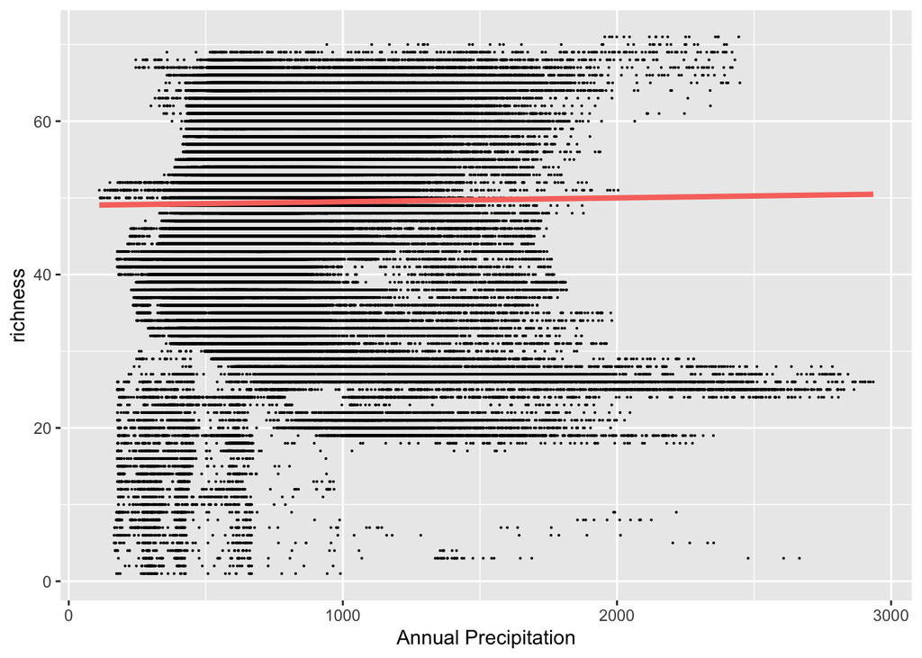

```r
prdat = data.frame(bio12 = seq(min(richness_df$bio12), max(richness_df$bio12), length.out=100))
prdat$richness = predict(mod1, newdata=prdat, type='response')

pts = ggplot(data = richness_df) + geom_point(aes(x=bio12, y=richness), size = 0.05) +
    xlab("Annual Precipitation")
m1_p = pts + geom_line(data = prdat, aes(x=bio12, y=richness), size = 1.4, colour = cols[1])
m1_p
```

We could continue as before, fitting polynomials to our data, but instead perhaps it makes sense to fit a different kind of model.

### 3.1 Generalised Additive Models

Generalised additive models are an extension of GLMs If a typical GLM fits a linear equation:

$L(\mathbb{E}(y)) = a + b_1x_1 + b_2x_2 + ... b_kx_k$

then a GAM extends this to fitting *non-linear* (smooth) functions of each x-variable:

$L(\mathbb{E}(y)) = a + f_1(x_1) + f_2(x_2) + ... f_k(x_k)$

Fitting a gam in R is simple.

```r
library(gam)
mod2 = gam(richness ~ s(bio12), family = "poisson", data = richness_df)
summary(mod2)
```

```
##
## Call: gam(formula = richness ~ s(bio12), family = "poisson", data = richness_df)
## Deviance Residuals:
##     Min      1Q  Median      3Q     Max
## -9.6212 -0.7910  0.2464  0.9667  6.6274
##
## (Dispersion Parameter for poisson family taken to be 1)
##
##     Null Deviance: 759618.3 on 283746 degrees of freedom
## Residual Deviance: 691939.2 on 283742 degrees of freedom
## AIC: 2311631
##
## Number of Local Scoring Iterations: NA
##
## Anova for Parametric Effects
##               Df Sum Sq Mean Sq F value    Pr(>F)
## s(bio12)       1    301 300.897  136.38 < 2.2e-16 ***
## Residuals 283742 626023   2.206
## ---
## Signif. codes:  0 '***' 0.001 '**' 0.01 '*' 0.05 '.' 0.1 ' ' 1
##
## Anova for Nonparametric Effects
##             Npar Df Npar Chisq    P(Chi)
## (Intercept)
## s(bio12)          3      64030 < 2.2e-16 ***
## ---
## Signif. codes:  0 '***' 0.001 '**' 0.01 '*' 0.05 '.' 0.1 ' ' 1
```

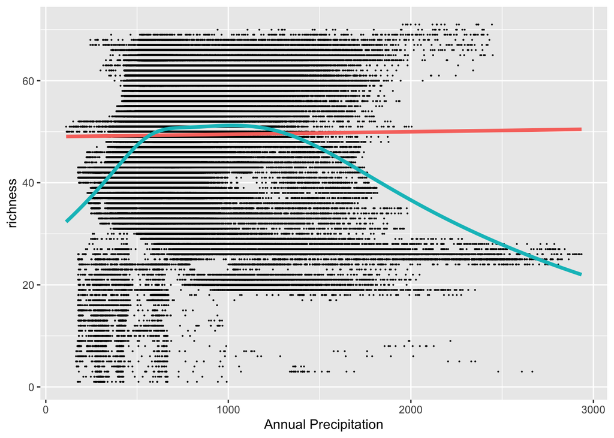

```r
prdat$richness2 = predict(mod2, newdata=prdat, type='response')
m2_p = m1_p + geom_line(data = prdat, aes(x=bio12, y=richness2), size = 1.4, colour = cols[3])
m2_p
```

The GAM produces a much curvier fit, and one that shows a hump in richness at intermediate precipitations. It certainly seems to be a better match to the cloud of points, but there is still a lot of scatter.

Note the `s` function in the GAM call. This stands for “smooth.” By specifying this, we are asking for a smooth curve to be fit to a variable. GAM can also fit linear terms, by including them as we do in a GLM. Also note the `df` parameter; this controls how curvy the line can be; if df=1, then the fit would be linear.

### 3.2 Spatial effects and contingency

We notice a lot of empty space on the above plot, an in particular a lot of strange gaps. Some precipitation values are not well-represented in the data, and there are some precip-richness combinations that just don’t exist. Thus, there could be a lot of things not related to precipitation that influence how this relationship looks. In particular, because we analyse diversity at every point on the map, we must be very careful in interpreting the results. Certainly p-values are biased and not to be trusted, but even the slope and/or shape of the relationship could be influenced quite a lot by confounding factors.

```r
mod3 = gam(richness ~ s(bio12) + s(x, df=5) + s(y, df=5) + s(x*y, df=5), family = "poisson", data = richness_df)
summary(mod3)
```

```
##
## Call: gam(formula = richness ~ s(bio12) + s(x, df = 5) + s(y, df = 5) +
##     s(x * y, df = 5), family = "poisson", data = richness_df)
## Deviance Residuals:
##       Min        1Q    Median        3Q       Max
## -10.23808  -0.33074   0.07579   0.40144   2.53041
##
## (Dispersion Parameter for poisson family taken to be 1)
##
##     Null Deviance: 759618.3 on 283746 degrees of freedom
## Residual Deviance: 190368.3 on 283727 degrees of freedom
## AIC: 1810090
##
## Number of Local Scoring Iterations: NA
##
## Anova for Parametric Effects
##                      Df Sum Sq Mean Sq F value    Pr(>F)
## s(bio12)              1  20816   20816   35124 < 2.2e-16 ***
## s(x, df = 5)          1  52267   52267   88194 < 2.2e-16 ***
## s(y, df = 5)          1  38669   38669   65250 < 2.2e-16 ***
## s(x * y, df = 5)      1 129707  129707  218863 < 2.2e-16 ***
## Residuals        283727 168148       1
## ---
## Signif. codes:  0 '***' 0.001 '**' 0.01 '*' 0.05 '.' 0.1 ' ' 1
##
## Anova for Nonparametric Effects
##                  Npar Df Npar Chisq    P(Chi)
## (Intercept)
## s(bio12)               3       6162 < 2.2e-16 ***
## s(x, df = 5)           4      26540 < 2.2e-16 ***
## s(y, df = 5)           4     235145 < 2.2e-16 ***
## s(x * y, df = 5)       4       4934 < 2.2e-16 ***
## ---
## Signif. codes:  0 '***' 0.001 '**' 0.01 '*' 0.05 '.' 0.1 ' ' 1
```

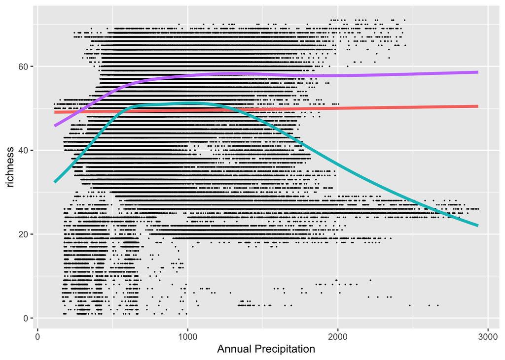

```r
prdat$x = (max(richness_df$x) - min(richness_df$x)) / 2 + min(richness_df$x)
prdat$y = (max(richness_df$y) - min(richness_df$y)) / 2 + min(richness_df$y)
prdat$richness3 = predict(mod3, newdata=prdat, type='response')
m3_p = m2_p + geom_line(data = prdat, aes(x=bio12, y=richness3), size = 1.4, colour = cols[4])
m3_p
```

Our new curve is looking much more sensible, richness generally increases with precipitation until it levels off. This suggests the decrease we saw with ther earlier models is due to other variables. Now we will try including them.

### 3.2 Model selection

Now comes the task of deciding which variables to include. Fortunately, AIC is also well-defined for GAM models, so we can use this as the basis of our comparison. Here we fit a full model, considering elevation, human influence, temperature, precipitation, temperature seasonality, and precipitation seasonality. We then follow this with a series of models dropping a single parameter at a time (not including space, we always retain this), and compare them all in a table using AIC.

Note that these are big models, so it is normal for this code to take some time to run.

```r
mod_f = gam(richness ~ s(bio1) + s(bio4) + s(bio12) + s(bio15) + s(elevation) + s(hii) +
            s(x, df=5) + s(y, df=5) + s(x*y, df=5), family = "poisson", data = richness_df)
mod_dbio1 = update(mod_f, ~.-s(bio1))
mod_dbio4 = update(mod_f, ~.-s(bio4))
mod_dbio12 = update(mod_f, ~.-s(bio12))
mod_dbio15 = update(mod_f, ~.-s(bio15))
mod_delevation = update(mod_f, ~.-s(elevation))
mod_dhii = update(mod_f, ~.-s(hii))

aic_tab = data.frame(names = c("full", "-bio1", "-bio4", "-bio12", "-bio15", "-elevation", "-hii"),
                     aic = c(AIC(mod_f), AIC(mod_dbio1), AIC(mod_dbio4), AIC(mod_dbio12), AIC(mod_dbio15), AIC(mod_delevation), AIC(mod_dhii)))
aic_tab$daic = aic_tab$aic - min(aic_tab$aic)
aicw_num = exp(-0.5 * aic_tab$daic)
aic_tab$weight = aicw_num / sum(aicw_num)

knitr::kable(aic_tab, digits = 3)
```

| names | aic | daic | weight |
| --- | --- | --- | --- |
| full | 1787355 | 0.000 | 1 |
| -bio1 | 1789873 | 2518.019 | 0 |
| -bio4 | 1795769 | 8414.134 | 0 |
| -bio12 | 1790064 | 2709.369 | 0 |
| -bio15 | 1789806 | 2450.888 | 0 |
| -elevation | 1788118 | 762.607 | 0 |
| -hii | 1787390 | 34.675 | 0 |

Here we compute AIC for each model, along with $\Delta \mathrm{AIC}$ and the Akaike weight. AIC alone is related to the log likelihood of the model, after penalising for model complexity; a lower AIC indicates a better-fitting model. $\Delta \mathrm{AIC}$ can be used to compare models within a single set. Here, the best model in the set will always have $\Delta \mathrm{AIC} = 0$, and worse models will have increasing $\Delta \mathrm{AIC}$. Although not hard and fast, a reasonable guideline is to consider models where $\Delta \mathrm{AIC} < 2$ as having strong support within the model set, and models with $\Delta \mathrm{AIC} < 10$ have some support (Anderson and Burnham 2004). Finally, Akaike weights can be interpreted as the probability, *conditional on the set of models under evaluation*, that a particular model is the best one.

Here, the full model is best, indicating that all of our variables are useful in describing species richness. Perhaps we could get away with dropping `hii`, but we have lots of data, so it is not really necessary. We can proceed from here to some visualisation and interpretation.

## 4. Interpretation

First, a last note about the Poisson assumption. At the beginning, we noted that for our Poisson model to meet its parametric assumption, the conditional mean and variance must be equal. We can check this using the ratio of the residual deviance to the fitted degrees of freedom. This is known as the *dispersion parameter* and for Poisson models it should be near one.

```r
round(deviance(mod_f) / mod_f$df.residual, 3)
```

```
## [1] 0.591
```

From here, this section is deliberately short. I first provide some code for producing partial a partial response plot, but I encourage you to explore the other variables on your own. What can we learn about the pattern of mammal species richness? Are any results surprising?

We create a partial response plot for the model using dummy data, as we have done before. Note that we must set each variable to a value in this case, because we have not centred the data to mean=0. We also stick to the geographic centre for interpeting the variables. However, it might also be useful to explore the geographic pattern while holding the other variables constant. How would you do this?

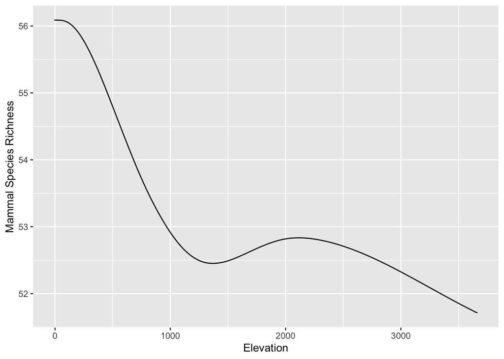

```r
pl_data = data.frame(
    bio1 = rep(mean(richness_df$bio1), 200),
    bio4 = mean(richness_df$bio4),
    bio12 = mean(richness_df$bio12),
    bio15 = mean(richness_df$bio15),
    elevation = mean(richness_df$elevation),
    hii = mean(richness_df$hii),
    x = (max(richness_df$x) - min(richness_df$x)) / 2 + min(richness_df$x),
    y = (max(richness_df$y) - min(richness_df$y)) / 2 + min(richness_df$y)
)

## set up a gradient in a single variable of interest
pl_data$elevation = seq(min(richness_df$elevation), max(richness_df$elevation), length.out = nrow(pl_data))

## generate predictions
pl_data$richness = predict(mod_f, newdata = pl_data, type='response')

## plot it
ggplot(pl_data) + geom_line(aes(x=elevation, y = richness)) + xlab("Elevation") + ylab("Mammal Species Richness")
```

```r
## don't forget to set the variable back to it's original value before looking at other variables
pl_data$elevation = mean(richness_df$elevation)
```

Finally, here we create a map of species richness, but using only endangered species. If you re-run the analysis, but using endangered species instead of all, how do the species richness patterns change?

```r
## produces one map per status
mamm_r_end = rasterize(mamm, clim_pres[[1]], fun = "sum", background = 0, by = "category")

## adds together near-threatened, vulnerable, endangered, and critically endangered
mamm_r_end = mamm_r_end[["NT"]] + mamm_r_end[["VU"]] + mamm_r_end[["EN"]] + mamm_r_end[["CR"]]

## make sure oceans have zero instead of NA
mamm_r_end = mask(mamm_r_end, mamm_r)

## from here, you could repeat the analysis starting from 2.3
```

## References

Anderson, D., and K. Burnham. “Model selection and multi-model inference.” Second. NY: Springer-Verlag 63.2020 (2004): 10.

[CC-BY 4.0](http://creativecommons.org/licenses/by/4.0/)